# index

GE2340 - Course Project - 2023/2024 Semester A  
MOIROUD William 40148105  
Sungjun Kim 56844492

Our goal with this website is to discuss a technology that we have discovered and experimented with. That's why this website will demonstrate how one can leverage AI in Financial Technologies, specifically focusing on how to utilize time series analysis in a prediction project. We have endeavored to provide detailed explanations throughout the code and offer interpretations of the various results obtained. The data utilized for this project is accessible on the following website (https://www.kaggle.com/datasets/rohanrao/nifty50-stock-market-data) and has been employed to ensure transparency and reproducibility in our analyses.  
Our main motivation was to discover the tools commonly used in the financial domain for predicting market prices. When we learned that Time Series Analysis is a viable approach, we decided to experiment on our own, and that is the primary focus of this website.

Project Overview: Time Series Analysis using GARCH Model

Objective: The project aims to conduct time series analysis on the daily returns of the S&P 500 stock market index. The analysis involves the application of an Autoregressive Generalized Autoregressive Conditional Heteroskedasticity (AR-GARCH) model with a skewed Student's t-distribution.

Data Collection and Preprocessing:

```
S&P 500 daily data is loaded using the arch library, and the adjusted closing prices are extracted.
Daily returns are calculated by taking the percentage change of the adjusted closing prices.
```

Modeling:

```
An AR-GARCH model is specified using the arch library, where volatility is modeled with a GARCH(1,1) process, and the distribution of innovations is assumed to be a skewed Student's t-distribution.
The model is fitted to the daily returns, and parameters are estimated using the maximum likelihood method.
```

Forecasting:

```
Forecasts are generated for the conditional mean and variance of the GARCH model starting from a specified date in 2018.
Quantiles for the skewed Student's t-distribution are computed based on the estimated model parameters.
```

Risk Assessment and Visualization:

```
Value at Risk (VaR) is calculated using the forecasted mean and variance along with quantiles.
VaR values are visualized over time.
Actual returns exceeding specific VaR thresholds are identified and marked on the plot with different colors and markers.
A legend is added for better interpretation.
```

Results and Interpretation:

```
The project provides insights into the volatility and risk of the S&P 500 based on the fitted AR-GARCH model.
The visualization helps assess the model's performance by comparing forecasted VaR with actual returns.
```

Conclusion: The time series analysis using the AR-GARCH model offers a robust framework for understanding and managing financial risk in the context of stock market returns. The project demonstrates proficiency in utilizing statistical models for financial time series analysis and visualization.

```python
import itertools
import pandas as pd
import numpy as np
from random import gauss

from statsmodels.graphics.tsaplots import plot_acf, plot_pacf
from statsmodels.stats.diagnostic import het_arch, acorr_ljungbox

from scipy.stats import shapiro
from scipy.stats import probplot

import matplotlib.pyplot as plt
plt.style.use('fivethirtyeight')

import warnings
warnings.simplefilter(action='ignore', category= FutureWarning)
```

```python
# general settings
class CFG:
    data_folder = '../input/tsdata-1/'
    img_dim1 = 20
    img_dim2 = 10

# adjust the parameters for displayed figures
plt.rcParams.update({'figure.figsize': (CFG.img_dim1,CFG.img_dim2)})
```

The code reads a CSV file containing stock data (specifically for the stock named 'TATASTEEL'), sets the "Date" column as the index, and then plots the percentage change of the VWAP column over time. This line calculates the percentage change of the "VWAP" (Volume Weighted Average Price) column in the DataFrame and then plots the result. The pct_change() function computes the percentage change between the current and a prior element.

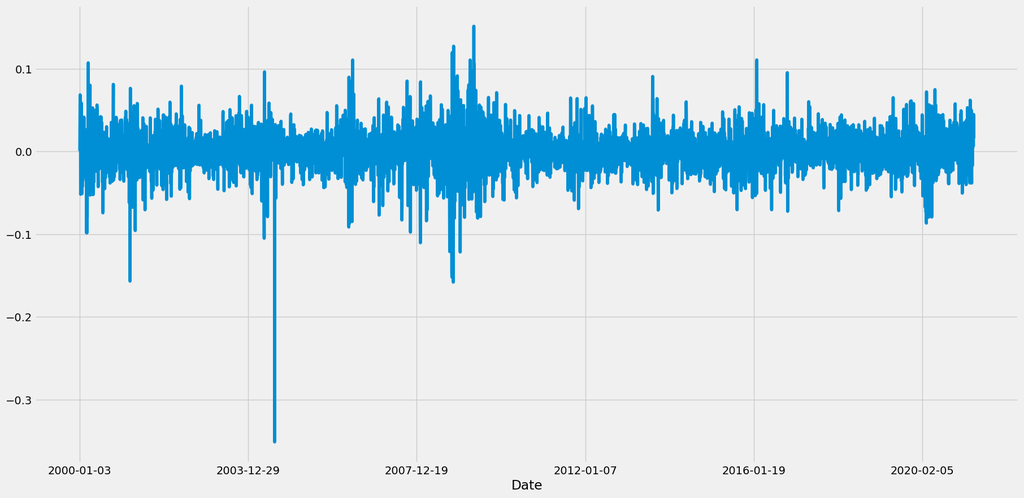

```python
stock_name = 'TATASTEEL'
df = pd.read_csv('./input/'+stock_name+'.csv')
df.set_index("Date", drop=False, inplace=True)

df.VWAP.pct_change().plot()
```

Here computes log-returns for the VWAP, plots the Autocorrelation Function for the log-returns, prints an empty line, and then plots the Autocorrelation Function for the squared log-returns. These analyses can provide insights into the autocorrelation and volatility clustering in the time series data.

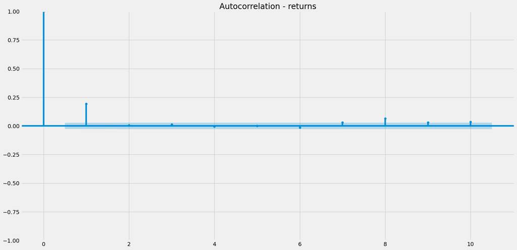

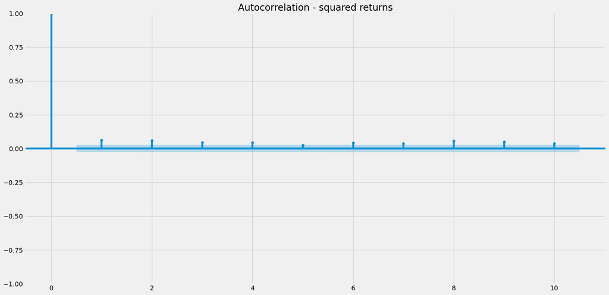

```python
dfl = np.log1p(df.VWAP).diff().dropna()
plot_acf(dfl, lags = 10, title='Autocorrelation - returns'); print()
plot_acf(dfl**2, lags = 10, title='Autocorrelation - squared returns'); print()
```

Here we compute and plot the Partial Autocorrelation Function (PACF) for both the log-returns and the squared log-returns. The PACF helps identify the direct relationship between an observation and its lags, providing insights into the potential order of an autoregressive model. The analysis can be useful in understanding the temporal dependencies in the time series data.

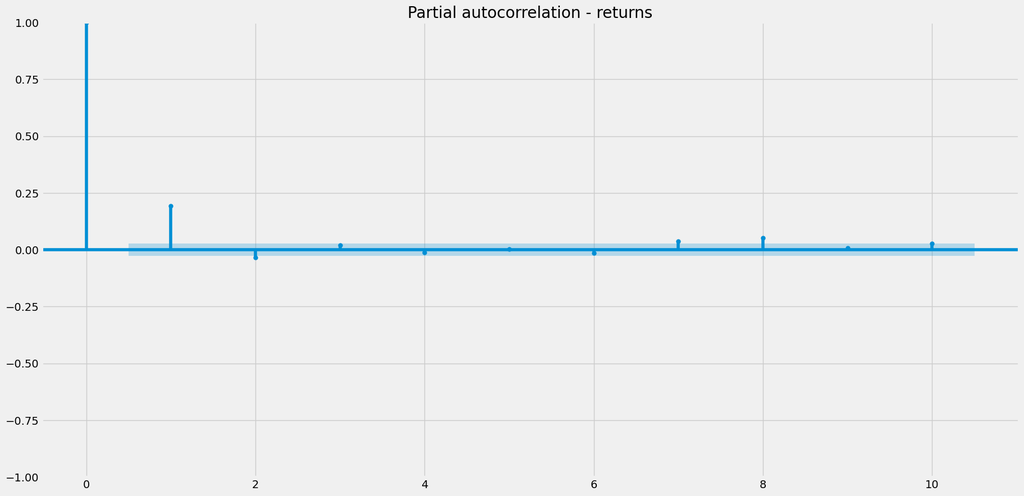

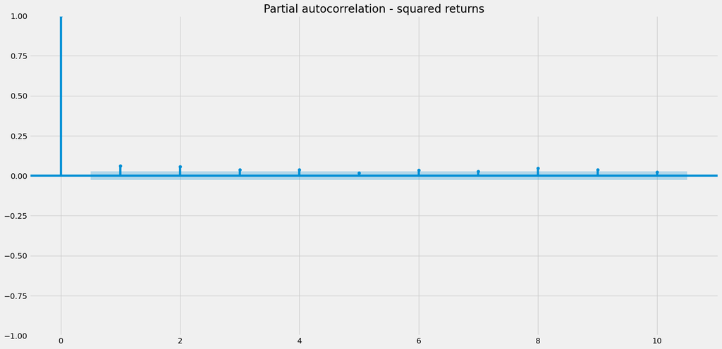

```python
plot_pacf(dfl, lags = 10, title='Partial autocorrelation - returns'); print()
plot_pacf(dfl**2, lags = 10, title='Partial autocorrelation - squared returns'); print()
```

We fit a GARCH(1,0) model to the log-returns series using the arch library and then print a summary of the fitted model. GARCH models are commonly used in financial econometrics to model volatility clustering and time-varying volatility in asset returns.

```python
from arch import arch_model

am = arch_model(100 * dfl, p = 1, q = 0)
res = am.fit(update_freq=5)
print(res.summary())
```

```
Iteration:      5,   Func. Count:     32,   Neg. LLF: 12129.135691668853
Optimization terminated successfully    (Exit mode 0)
            Current function value: 12129.1066722275
            Iterations: 8
            Function evaluations: 43
            Gradient evaluations: 8
                      Constant Mean - ARCH Model Results
==============================================================================
Dep. Variable:                   VWAP   R-squared:                       0.000
Mean Model:             Constant Mean   Adj. R-squared:                  0.000
Vol Model:                       ARCH   Log-Likelihood:               -12129.1
Distribution:                  Normal   AIC:                           24264.2
Method:            Maximum Likelihood   BIC:                           24283.9
                                        No. Observations:                 5305
Date:                Sun, Dec 03 2023   Df Residuals:                     5304
Time:                        15:21:51   Df Model:                            1
                                 Mean Model
===========================================================================
                 coef    std err          t      P>|t|     95.0% Conf. Int.
---------------------------------------------------------------------------
mu             0.0334  3.424e-02      0.975      0.330 [-3.373e-02,  0.100]
                            Volatility Model
========================================================================
                 coef    std err          t      P>|t|  95.0% Conf. Int.
------------------------------------------------------------------------
omega          4.7014      0.580      8.109  5.085e-16 [  3.565,  5.838]
alpha[1]       0.2268  5.178e-02      4.380  1.187e-05 [  0.125,  0.328]
========================================================================

Covariance estimator: robust
```

Now let's explain the following plots :

1. Standardized Residuals: These are the residuals of the model standardized by the conditional volatility. Standardized residuals help assess whether the model adequately captures the patterns in the data. If there are significant patterns or trends in the standardized residuals, it may suggest that the model does not fully capture the information in the data.
2. Conditional Volatility: This represents the time-varying volatility predicted by the GARCH model. Examining conditional volatility helps understand how volatility changes over time. Sudden spikes in conditional volatility might correspond to periods of high market uncertainty or unexpected events.

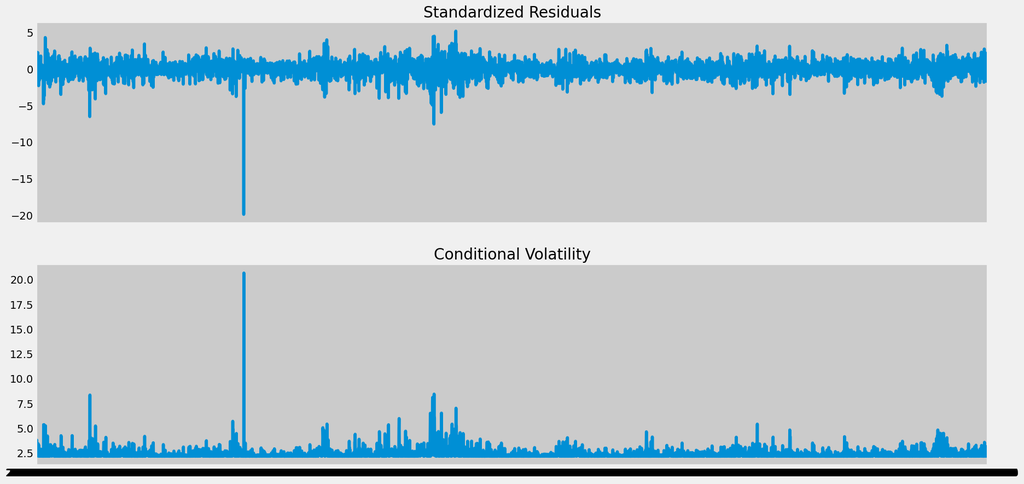

```python
res.plot(); print()
```

We now calculate the standardized residuals by dividing the raw residuals by the conditional volatility, which is a common step in the evaluation of GARCH models to check for patterns or anomalies in the standardized residuals. The max_lags variable, although defined, is not used directly in this snippet and its purpose would depend on the broader context of the code.

```python
max_lags = 5
residuals = res.resid
st_residuals = np.divide(res.resid, res.conditional_volatility)
```

This code is generating an ACF plot for the squared log-returns series, which can provide insights into the presence of autocorrelation in the squared log-returns data. This type of analysis is often used in financial time series to understand volatility clustering.

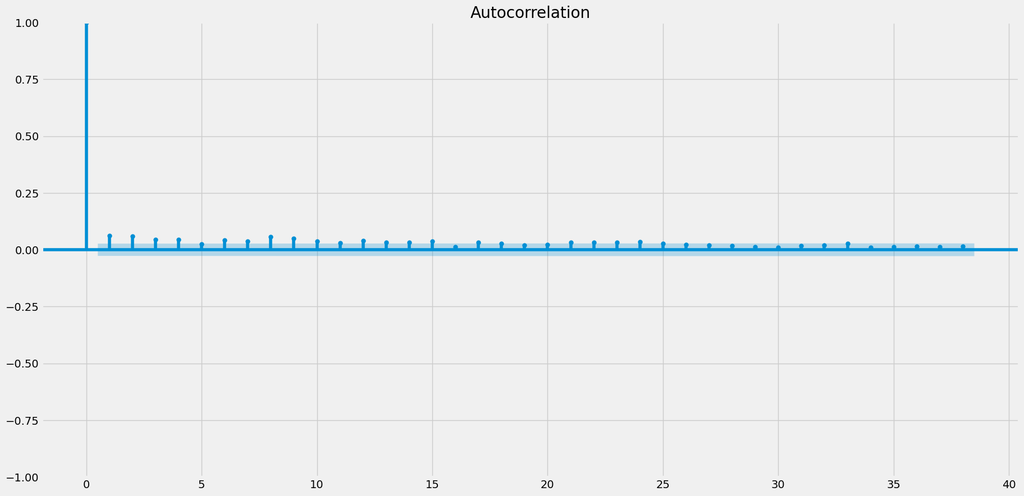

```python
plot_acf(dfl ** 2); print()
```

The code is performing a Ljung-Box test on the squared log-returns up to a specified number of lags (max_lags). The loop then prints the lag and the rounded p-value for each lag, providing information about the statistical significance of autocorrelations at different lags in the squared log-returns series.

```python
# Ljung-Box

lb_test = acorr_ljungbox(dfl ** 2 , lags = max_lags)
print(lb_test)
for lag in range(max_lags):
    value = lb_test["lb_pvalue"].iloc[lag]
    rou = np.round(value, 4)
    print('lag: ' + str(lag) + ' pval: ' + str(rou) )
```

```
     lb_stat     lb_pvalue
1  19.964970  7.887399e-06
2  38.996594  3.404060e-09
3  49.365869  1.090274e-10
4  59.783425  3.221337e-12
5  63.367823  2.442687e-12
lag: 0 pval: 0.0
lag: 1 pval: 0.0
lag: 2 pval: 0.0
lag: 3 pval: 0.0
lag: 4 pval: 0.0
```

This code is performing a Ljung-Box test on the squared standardized residuals up to a specified number of lags (max_lags). The loop then prints the lag and the rounded p-value for each lag, providing information about the statistical significance of autocorrelations at different lags in the squared standardized residuals series. This type of analysis is often used to check for autocorrelation in the squared standardized residuals, which is relevant in the context of volatility modeling.

```python
lb_test = acorr_ljungbox(st_residuals ** 2 , lags = max_lags)
for lag in range(max_lags):
    rou = np.round( lb_test["lb_pvalue"].iloc[lag], 4)
    print('lag: ' + str(lag) + ' pval: ' + str( rou))
```

```
lag: 0 pval: 0.7807
lag: 1 pval: 0.4318
lag: 2 pval: 0.5617
lag: 3 pval: 0.4001
lag: 4 pval: 0.5123
```

This code is performing Engle's ARCH test on the log-returns series up to a specified maximum lag (maxlag). It then prints the p-values from both the Lagrange Multiplier (LM) test and the F-test. These p-values are used to assess the statistical significance of conditional heteroskedasticity in the log-returns series. If the p-values are below a certain significance level (commonly 0.05), it may suggest the presence of conditional heteroskedasticity in the data.

```python
# Engle ARCH
etest = het_arch(dfl, maxlag=5)
print('pval Lagrange: ' + str(np.round(etest[1],4)))
print('pval F-test: ' + str(np.round(etest[1],4)))
```

```
pval Lagrange: 0.0
pval F-test: 0.0
```

This code is performing Engle's ARCH test on the squared standardized residuals up to a specified maximum lag (maxlag). It then prints the p-values from both the Lagrange Multiplier (LM) test and the F-test. These p-values are used to assess the statistical significance of conditional heteroskedasticity in the squared standardized residuals series. If the p-values are below a certain significance level (commonly 0.05), it may suggest the presence of conditional heteroskedasticity in the data.

```python
etest = het_arch(st_residuals, maxlag=5)
print('pval Lagrange: ' + str(np.round(etest[1],4)))
print('pval F-test: ' + str(np.round(etest[1],4)))
```

```
pval Lagrange: 0.5195
pval F-test: 0.5195
```

This code is fitting a GARCH(1,1) model to the log-returns series, and it prints a detailed summary of the fitted model. This type of modeling is commonly used in financial time series analysis to capture volatility clustering and time-varying volatility in asset returns.

```python
gm = arch_model(100 * dfl, p = 1, q = 1)
res = gm.fit(update_freq=5)
print(res.summary())
```

```
Iteration:      5,   Func. Count:     34,   Neg. LLF: 11838.126029106981
Iteration:     10,   Func. Count:     65,   Neg. LLF: 11835.563882450348
Optimization terminated successfully    (Exit mode 0)
            Current function value: 11835.56177652276
            Iterations: 13
            Function evaluations: 80
            Gradient evaluations: 13
                     Constant Mean - GARCH Model Results
==============================================================================
Dep. Variable:                   VWAP   R-squared:                       0.000
Mean Model:             Constant Mean   Adj. R-squared:                  0.000
Vol Model:                      GARCH   Log-Likelihood:               -11835.6
Distribution:                  Normal   AIC:                           23679.1
Method:            Maximum Likelihood   BIC:                           23705.4
                                        No. Observations:                 5305
Date:                Sun, Dec 03 2023   Df Residuals:                     5304
Time:                        16:13:37   Df Model:                            1
                                  Mean Model
=============================================================================
                 coef    std err          t      P>|t|       95.0% Conf. Int.
-----------------------------------------------------------------------------
mu             0.0156  3.322e-02      0.471      0.638 [-4.947e-02,8.074e-02]
                              Volatility Model
============================================================================
                 coef    std err          t      P>|t|      95.0% Conf. Int.
----------------------------------------------------------------------------
omega          0.0327  4.482e-02      0.729      0.466  [-5.518e-02,  0.121]
alpha[1]       0.0414  1.580e-02      2.621  8.771e-03 [1.044e-02,7.236e-02]
beta[1]        0.9552  2.497e-02     38.257      0.000     [  0.906,  1.004]
============================================================================

Covariance estimator: robust
```

The loop iterates over each lag up to max_lags and prints the lag number and the rounded p-value from the Ljung-Box test for the squared residuals. This provides information about the statistical significance of autocorrelations in the squared residuals at different lags. If the p-values are below a certain significance level (commonly 0.05), it may suggest the presence of autocorrelation in the squared residuals.

```python
# Ljung-Box
residuals = res.resid
st_residuals = np.divide(res.resid, res.conditional_volatility)
lb_test = acorr_ljungbox(residuals ** 2 , lags = max_lags)
for lag in range(max_lags):
    print('lag: ' + str(lag) + ' pval: ' + str(np.round( lb_test["lb_pvalue"].iloc[lag], 4) ))
```

```
lag: 0 pval: 0.0
lag: 1 pval: 0.0
lag: 2 pval: 0.0
lag: 3 pval: 0.0
lag: 4 pval: 0.0
```

The loop iterates over each lag up to max_lags and prints the lag number and the rounded p-value from the Ljung-Box test for the squared standardized residuals. This provides information about the statistical significance of autocorrelations in the squared standardized residuals at different lags. If the p-values are below a certain significance level (commonly 0.05), it may suggest the presence of autocorrelation in the squared standardized residuals.

```python
lb_test = acorr_ljungbox(st_residuals ** 2 , lags = max_lags)
for lag in range(max_lags):
    print('lag: ' + str(lag) + ' pval: ' + str(np.round( lb_test["lb_pvalue"].iloc[lag], 4) ))
```

```
lag: 0 pval: 0.6719
lag: 1 pval: 0.8725
lag: 2 pval: 0.9573
lag: 3 pval: 0.9886
lag: 4 pval: 0.9966
```

This code is performing Engle's ARCH test on the log-returns series up to a specified maximum lag (maxlag). It then prints the p-values from both the Lagrange Multiplier (LM) test and the F-test. These p-values are used to assess the statistical significance of conditional heteroskedasticity in the log-returns series. If the p-values are below a certain significance level (commonly 0.05), it may suggest the presence of conditional heteroskedasticity in the data.

```python
# Engle ARCH
etest = het_arch(dfl, maxlag=5)
print('pval Lagrange: ' + str(np.round(etest[1],4)))
print('pval F-test: ' + str(np.round(etest[1],4)))
```

```
pval Lagrange: 0.0
pval F-test: 0.0
```

This code is performing Engle's ARCH test on the squared standardized residuals up to a specified maximum lag (maxlag). It then prints the p-values from both the Lagrange Multiplier (LM) test and the F-test. These p-values are used to assess the statistical significance of conditional heteroskedasticity in the squared standardized residuals series. If the p-values are below a certain significance level (commonly 0.05), it may suggest the presence of conditional heteroskedasticity in the data.

```python
etest = het_arch(st_residuals, maxlag=5)
print('pval Lagrange: ' + str(np.round(etest[1],4)))
print('pval F-test: ' + str(np.round(etest[1],4)))
```

```
pval Lagrange: 0.9966
pval F-test: 0.9966
```

This line fits the AR model to the scaled log-returns series and prints a summary of the fitted model. The fit() method is called to estimate the parameters of the AR model, and summary() provides detailed information about the estimated parameters, standard errors, t-values, and other statistics.

In summary, this code fits an autoregressive model with lags 1 and 3 to the scaled log-returns series and prints a summary of the fitted model. The AR model is commonly used to capture linear dependencies in time series data by modeling the current value as a linear combination of past values.

```python
from arch.univariate import ARX

ar = ARX(100 * dfl, lags=[1, 3])
print(ar.fit().summary())
```

```
                     AR - Constant Variance Model Results
==============================================================================
Dep. Variable:                   VWAP   R-squared:                       0.038
Mean Model:                        AR   Adj. R-squared:                  0.037
Vol Model:          Constant Variance   Log-Likelihood:               -12185.4
Distribution:                  Normal   AIC:                           24378.9
Method:            Maximum Likelihood   BIC:                           24405.2
                                        No. Observations:                 5302
Date:                Sun, Dec 03 2023   Df Residuals:                     5299
Time:                        15:37:30   Df Model:                            3
                                  Mean Model
=============================================================================
                 coef    std err          t      P>|t|       95.0% Conf. Int.
-----------------------------------------------------------------------------
Const          0.0270  3.328e-02      0.810      0.418 [-3.826e-02,9.220e-02]
VWAP[1]        0.1933  2.186e-02      8.842  9.377e-19      [  0.150,  0.236]
VWAP[3]        0.0123  1.968e-02      0.626      0.531 [-2.625e-02,5.089e-02]
                            Volatility Model
========================================================================
                 coef    std err          t      P>|t|  95.0% Conf. Int.
------------------------------------------------------------------------
sigma2         5.8047      0.397     14.634  1.696e-48 [  5.027,  6.582]
========================================================================

Covariance estimator: White's Heteroskedasticity Consistent Estimator
```

In summary, this code combines an autoregressive (AR) model with a GARCH model for volatility in a unified framework. The AR component captures the linear dependencies in the log-returns series, while the GARCH component models the time-varying volatility. The final fitted model is then summarized and printed.

```python
from arch.univariate import ARCH, GARCH

ar.volatility = GARCH(p=1, q = 1)
res = ar.fit(update_freq=0, disp="off")
print(res.summary())
```

```
                           AR - GARCH Model Results
==============================================================================
Dep. Variable:                   VWAP   R-squared:                       0.037
Mean Model:                        AR   Adj. R-squared:                  0.037
Vol Model:                      GARCH   Log-Likelihood:               -11726.4
Distribution:                  Normal   AIC:                           23464.8
Method:            Maximum Likelihood   BIC:                           23504.2
                                        No. Observations:                 5302
Date:                Sun, Dec 03 2023   Df Residuals:                     5299
Time:                        15:37:42   Df Model:                            3
                                  Mean Model
==============================================================================
                  coef    std err          t      P>|t|       95.0% Conf. Int.
------------------------------------------------------------------------------
Const           0.0116  3.169e-02      0.366      0.715 [-5.053e-02,7.371e-02]
VWAP[1]         0.2036  1.518e-02     13.414  4.997e-41      [  0.174,  0.233]
VWAP[3]    -2.9844e-03  1.489e-02     -0.200      0.841 [-3.217e-02,2.620e-02]
                              Volatility Model
============================================================================
                 coef    std err          t      P>|t|      95.0% Conf. Int.
----------------------------------------------------------------------------
omega          0.0301  4.046e-02      0.745      0.457  [-4.917e-02,  0.109]
alpha[1]       0.0412  1.385e-02      2.977  2.909e-03 [1.409e-02,6.837e-02]
beta[1]        0.9557  2.269e-02     42.121      0.000     [  0.911,  1.000]
============================================================================

Covariance estimator: robust
```

These diagnostic plots are crucial for assessing the goodness of fit and identifying potential issues with the model. The standardised residuals plot can help you check for any patterns or outliers in the residuals, while the conditional volatility plot provides insights into the volatility dynamics captured by the GARCH model.

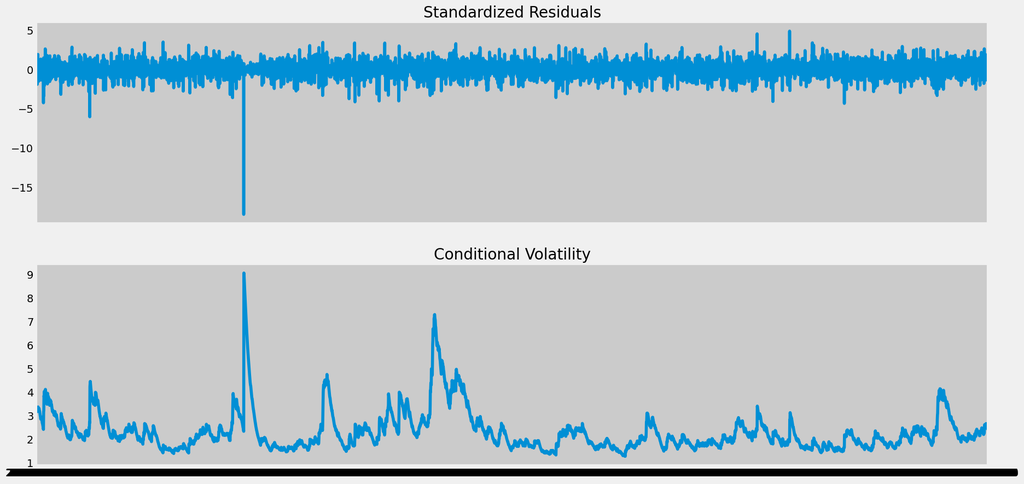

```python
fig = res.plot()
```

```python
dfl = np.log1p(df.VWAP).diff().dropna()
print(dfl.index.min(), dfl.index.max())
```

```
2000-01-04 2021-04-30
```

```python
# split into training and validation
xtr, xval = dfl.loc[:'2021-01-01'], dfl.loc['2021-01-01':]
```

We now fit an autoregressive model with a lag of 1 and a GARCH(1,1) volatility model to our training data, then prints a summary of the fitted model.

```python
# fit the model
ar = ARX(100 * xtr, lags=[1])
ar.volatility = GARCH(p=1, q = 1)
res = ar.fit(update_freq=0, disp="off")
print(res.summary())
```

```
                           AR - GARCH Model Results
==============================================================================
Dep. Variable:                   VWAP   R-squared:                       0.037
Mean Model:                        AR   Adj. R-squared:                  0.037
Vol Model:                      GARCH   Log-Likelihood:               -11547.9
Distribution:                  Normal   AIC:                           23105.7
Method:            Maximum Likelihood   BIC:                           23138.5
                                        No. Observations:                 5225
Date:                Sun, Dec 03 2023   Df Residuals:                     5223
Time:                        15:39:51   Df Model:                            2
                                  Mean Model
=============================================================================
                 coef    std err          t      P>|t|       95.0% Conf. Int.
-----------------------------------------------------------------------------
Const      7.6358e-03  3.177e-02      0.240      0.810 [-5.463e-02,6.990e-02]
VWAP[1]        0.2039  1.536e-02     13.275  3.216e-40      [  0.174,  0.234]
                              Volatility Model
============================================================================
                 coef    std err          t      P>|t|      95.0% Conf. Int.
----------------------------------------------------------------------------
omega          0.0301  4.041e-02      0.746      0.456  [-4.908e-02,  0.109]
alpha[1]       0.0413  1.396e-02      2.959  3.090e-03 [1.394e-02,6.865e-02]
beta[1]        0.9556  2.285e-02     41.826      0.000     [  0.911,  1.000]
============================================================================

Covariance estimator: robust
```

The code is generating a forecast using the AR-GARCH model and then organizing the forecasted values along with actual values into a DataFrame for further analysis or visualization.

```python
# build the forecast
xfor = res.forecast(horizon= xval.shape[0])

# ugly workaround, I know
mean_forecast = xfor.mean.tail(1).values.reshape(len(xval),1)

forecast = pd.DataFrame()
forecast['Date'] = xval.index
forecast['VWAP'] = xval.values
forecast['fc_mean'] = xfor.mean.tail(1).values.reshape(len(xval),1)
forecast['fc_std'] = np.sqrt(xfor.variance.tail(1).values.reshape(len(xval),1))
```

```python
forecast
```

|  | Date | VWAP | fc_mean | fc_std |
| --- | --- | --- | --- | --- |
| 0 | 2021-01-01 | -0.000635 | -0.005309 | 1.956875 |
| 1 | 2021-01-04 | 0.044198 | 0.006553 | 2.001682 |
| 2 | 2021-01-05 | 0.013379 | 0.008972 | 2.008021 |
| 3 | 2021-01-06 | 0.003357 | 0.009466 | 2.012758 |
| 4 | 2021-01-07 | 0.048117 | 0.009566 | 2.017403 |
| ... | ... | ... | ... | ... |
| 75 | 2021-04-26 | 0.013062 | 0.009592 | 2.293164 |
| 76 | 2021-04-27 | 0.023504 | 0.009592 | 2.296414 |
| 77 | 2021-04-28 | 0.006857 | 0.009592 | 2.299650 |
| 78 | 2021-04-29 | 0.043910 | 0.009592 | 2.302871 |
| 79 | 2021-04-30 | 0.015798 | 0.009592 | 2.306077 |

80 rows × 4 columns

the code loads the S&P 500 dataset, extracts the adjusted closing prices, calculates daily returns as percentages, and scales them by a factor of 100. The resulting returns series represents the daily percentage returns of the S&P 500.

```python
import arch.data.sp500

data = arch.data.sp500.load()
market = data["Adj Close"]
returns = 100 * market.pct_change().dropna()
```

The code is fitting a GARCH(1,1) model with a skewed Student's t-distribution to the daily returns of the S&P 500 and suppressing the display of optimization convergence information.

```python
am = arch_model(returns, vol="Garch", p=1, o=0, q=1, dist="skewt")
res = am.fit(disp="off", last_obs="2017-12-31")
```

The code generates forecasts for the conditional mean and variance of the GARCH model, extracts forecasts starting from the year 2018, and computes quantiles for the skewed Student's t-distribution based on the estimated model parameters. The quantiles are then printed.

```python
forecasts = res.forecast(start="2018-1-1", reindex=False)
cond_mean = forecasts.mean["2018":]
cond_var = forecasts.variance["2018":]
q = am.distribution.ppf([0.01, 0.05], res.params[-2:])
print(q)
```

```
[-2.64484999 -1.64965918]
```

The code calculates parametric VaR based on the GARCH model, creates a plot of the VaR values, and overlays scatter points to visualize actual returns exceeding specific VaR thresholds for the year 2018. Different colors and markers are used to distinguish between different levels of exceedance. The legend provides information about the colors and their corresponding labels.

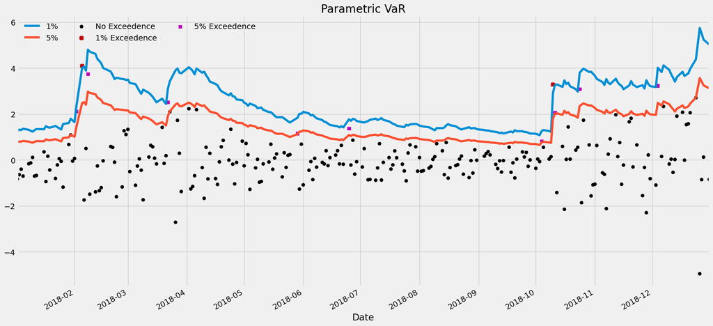

```python
value_at_risk = -cond_mean.values - np.sqrt(cond_var).values * q[None, :]
value_at_risk = pd.DataFrame(value_at_risk, columns=["1%", "5%"], index=cond_var.index)
ax = value_at_risk.plot(legend=False)
xl = ax.set_xlim(value_at_risk.index[0], value_at_risk.index[-1])
rets_2018 = returns["2018":].copy()
rets_2018.name = "S&P 500 Return"
c = []
for idx in value_at_risk.index:
    if rets_2018[idx] > -value_at_risk.loc[idx, "5%"]:
        c.append("#000000")
    elif rets_2018[idx] < -value_at_risk.loc[idx, "1%"]:
        c.append("#BB0000")
    else:
        c.append("#BB00BB")
c = np.array(c, dtype="object")
labels = {"#BB0000": "1% Exceedence", "#BB00BB": "5% Exceedence", "#000000": "No Exceedence",}
markers = {"#BB0000": "x", "#BB00BB": "s", "#000000": "o"}
for color in np.unique(c):
    sel = c == color
    ax.scatter(
        rets_2018.index[sel],
        -rets_2018.loc[sel],
        marker=markers[color],
        c=c[sel],
        label=labels[color],
    )
ax.set_title("Parametric VaR")
leg = ax.legend(frameon=False, ncol=3)
```

Reference : https://www.youtube.com/watch?v=74rDhJexmTg&ab_channel=AbhishekThakur  
https://www.kaggle.com/code/konradb/ts-0-the-basics/notebook  
https://www.kaggle.com/datasets/rohanrao/nifty50-stock-market-data  
https://www.investopedia.com/how-to-use-artificial-intelligence-in-your-investing-7973810